# Spring 2018 DATA606 Final Project Proposal

Jonathan Hernandez

April 30, 2018

This is the DATA606 Project Proposal. This project will look at a historical NYC

School Progress Report dataset from 2006-2007.

Research Question:

Is the overall school rating predictive of various categorical scores as well as

predictive of Borough of the school, grades and school level?

Cases:

There are

```
## [1] 1262
```

in the dataset.

Type of Study:

This is an observational study on past data.

Data Source:

Dataset is available here:

https://data.cityofnewyork.us/Education/2006-2007-School-Progress-Report/weg5-33pj

The data comes from the NYC OpenData website provided by the Department of Education (DOE).

Explanatory Variables:

The explanatory variables in question are:

- DBN (District Borough Number) - categorical
- SCHOOL LEVEL - categorical
- GRADE - categorical ordinal
- ENVIRONMENT CATEGORY SCORE - numerical continous
- PERFORMANCE CATEGORY SCORE - numerical continous
- PROGRESS CATEGORY SCORE - numerical continous
- QUALITY REVIEW SCORE - categorical ordinal

Response Variable

The response variable is

- OVERALL SCORE - numerical continous

Relevant Summary Statistics:

- Understanding the structure and summary

```r
str(school_progress_report_scores)
```

```
## 'data.frame':    1262 obs. of  14 variables:
##  $ DBN                                : Factor w/ 1226 levels "01M015","01M019",..: 1 2 3 4 5 6 7 8 9 10 ...
##  $ DISTRICT                           : int  1 1 1 1 1 1 1 1 1 1 ...
##  $ SCHOOL                             : Factor w/ 1224 levels "47 THE AMERICAN SIGN LANGUAGE AND ENGLISH DUAL LAN",..: 502 513 518 558 640 643 749 808 812 821 ...
##  $ SCHOOL.SUPPORT.ORGANIZATION.NETWORK: Factor w/ 74 levels "AED1","CEIPEA1",..: 45 16 45 45 45 16 16 45 55 26 ...
##  $ PROGRESS.REPORT.TYPE               : Factor w/ 2 levels "ESMS","HS": 1 1 1 1 1 1 1 1 1 1 ...
##  $ SCHOOL.LEVEL.                      : Factor w/ 5 levels "Elementary School",..: 1 1 1 3 1 1 1 1 1 3 ...
##  $ PEER.INDEX.                        : Factor w/ 812 levels " 10.20 "," 10.44 ",..: 659 425 536 572 443 572 393 492 553 605 ...
##  $ GRADE                              : Factor w/ 6 levels "A","B","C","D",..: 2 2 2 3 3 3 2 2 2 2 ...
##  $ OVERALL.SCORE                      : Factor w/ 1113 levels "-0.447","100",..: 513 483 517 367 302 403 480 571 728 631 ...
##  $ ENVIRONMENT.CATEGORY.SCORE         : Factor w/ 599 levels "-0.008","-0.019",..: 93 301 354 207 44 349 546 142 198 372 ...
##  $ PERFORMANCE.CATEGORY.SCORE         : Factor w/ 602 levels "0.006","-0.025",..: 46 219 418 127 261 330 384 297 123 195 ...
##  $ PROGRESS.CATEGORY.SCORE            : Factor w/ 589 levels "-0.021","0.03",..: 477 304 200 323 272 205 124 357 518 384 ...
##  $ ADDITIONAL.CREDIT                  : Factor w/ 21 levels "0","0.75","1",..: 9 6 6 2 1 1 8 6 2 6 ...
##  $ QUALITY.REVIEW.SCORE               : Factor w/ 4 levels "","Proficient",..: 3 2 4 2 2 4 2 4 3 2 ...
```

Data Cleanup:

Convert score variables to numeric from factor

```r
school_progress_report_scores$ENVIRONMENT.CATEGORY.SCORE <-
  as.numeric(as.character(school_progress_report_scores$ENVIRONMENT.CATEGORY.SCORE))
school_progress_report_scores$PERFORMANCE.CATEGORY.SCORE <-
  as.numeric(as.character(school_progress_report_scores$PERFORMANCE.CATEGORY.SCORE))
school_progress_report_scores$PROGRESS.CATEGORY.SCORE <-
  as.numeric(as.character(school_progress_report_scores$PROGRESS.CATEGORY.SCORE))
school_progress_report_scores$OVERALL.SCORE <-
  as.numeric(as.character(school_progress_report_scores$OVERALL.SCORE))
```

Exploratory Data Analysis:

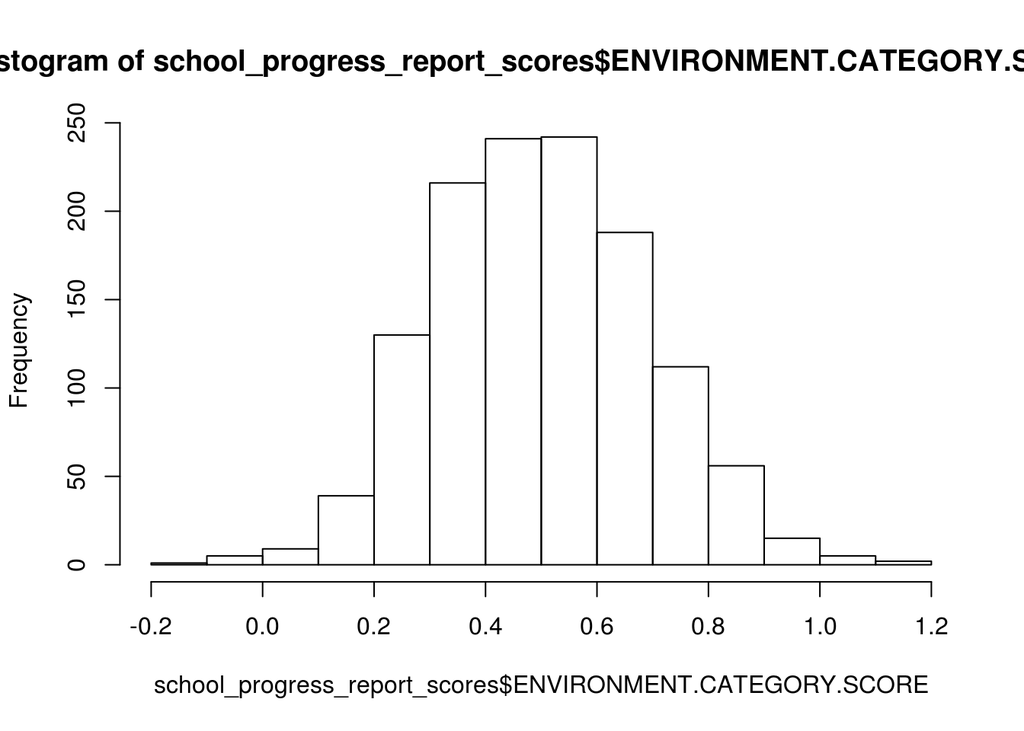

```r
hist(school_progress_report_scores$ENVIRONMENT.CATEGORY.SCORE)
```

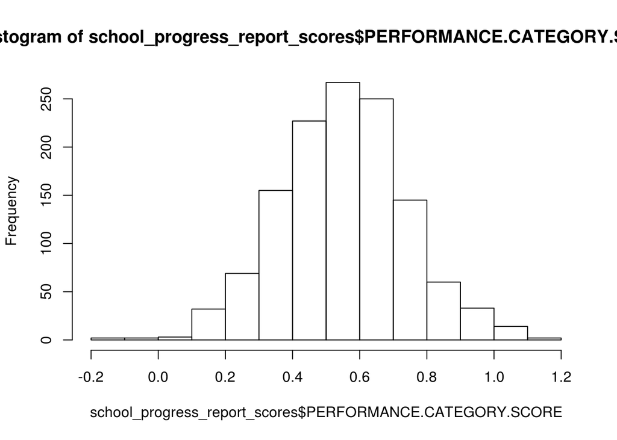

```r
hist(school_progress_report_scores$PERFORMANCE.CATEGORY.SCORE)
```

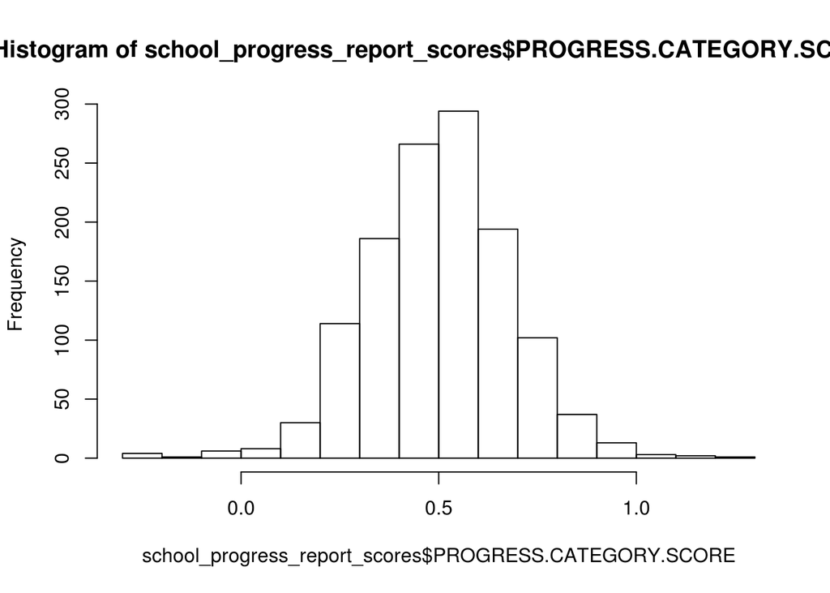

```r
hist(school_progress_report_scores$PROGRESS.CATEGORY.SCORE)
```

The 3 histograms of our numerical predictors are very near-normal

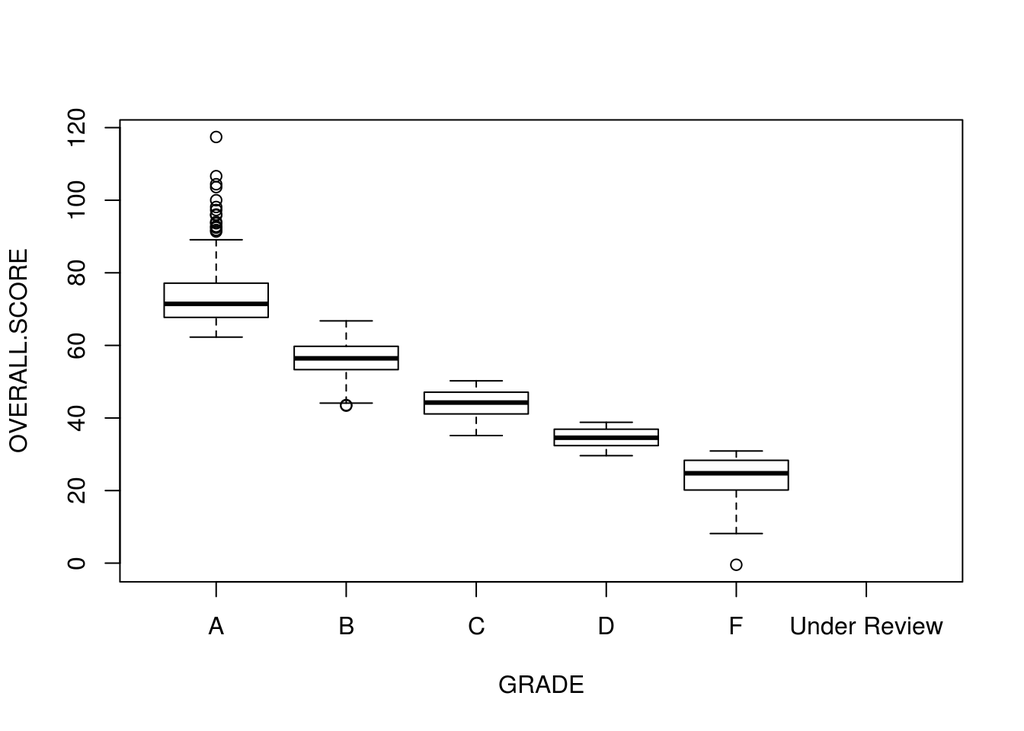

```r
with(school_progress_report_scores, plot(OVERALL.SCORE ~ GRADE))
```

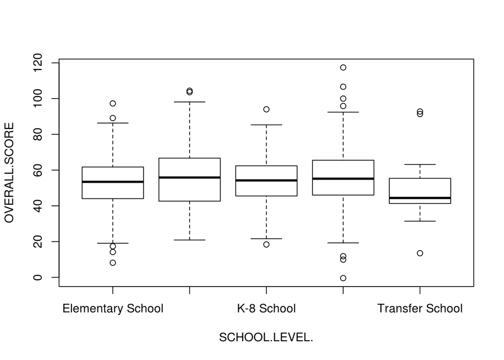

```r
with(school_progress_report_scores, plot(OVERALL.SCORE ~ SCHOOL.LEVEL.))
```